# CSP-571 Project Spring 24

Kyung Jin Kwak (kkwak4@hawk.iit.edu), Srujan Ramesh (sramesh19@hawk.iit.edu)

## Install necessary libraries

```r
library(ggplot2)
library(dplyr)
library(tidyr)
library(knitr)
library(formattable)
library(randomForest)
library(leaps)
library(splines)
library(caret)
library(glmnet)
library(tidyverse)
library(cluster)
library(factoextra)
```

## Loading & Checking Data

```r
taxi_df <- read.csv("../taxi_Trips__2024.csv")
```

```r
head(taxi_df)
```

```r
colSums(is.na(taxi_df))
```

```r
(unique(taxi_df$Company))
```

## Understanding the features

```r
feature_desc <- read.csv("taxi_Trips_2024_Feature_descriptions.csv")
feature_desc
```

```r
notes <- list()
for (feature in names(taxi_df)) {

  curr_note <- paste("Valid rows:",(nrow(taxi_df) - sum(is.na(taxi_df[,feature]))),
                     "; N/A rows:", sum(is.na(taxi_df[,feature])),
                     "; Unique values:", length(unique(taxi_df[,feature])))
  notes <- append(notes, curr_note)
}
notes
```

```r
feature_desc$Notes <- unlist(notes)
feature_desc
```

```r
# Install the formattable package if not already installed
if (!require(formattable)) {
  install.packages("formattable")
}

formattable(feature_desc, align = c("l", "l", "l", "l"), list(Notes = formatter("span", style = "color:blue"), Type = formatter("span", style = "color:green"))
)
```

```r
length(which(taxi_df$Fare + taxi_df$Tips + taxi_df$Tolls + taxi_df$Extras != taxi_df$Trip.Total))
```

## 1. Data Cleaning

### 1.1 Dropping unwanted features

```r
features_to_drop <- c("Trip.End.Timestamp", "Pickup.Census.Tract", "Dropoff.Census.Tract", "Pickup.Centroid.Latitude", "Pickup.Centroid.Longitude", "Pickup.Centroid.Location", "Dropoff.Centroid.Latitude", "Dropoff.Centroid.Longitude", "Dropoff.Centroid..Location")

simplified_taxi_df <- subset(taxi_df, select = -c(Trip.End.Timestamp, Pickup.Census.Tract, Dropoff.Census.Tract, Pickup.Centroid.Latitude, Pickup.Centroid.Longitude, Pickup.Centroid.Location, Dropoff.Centroid.Latitude, Dropoff.Centroid.Longitude, Dropoff.Centroid..Location))
head(simplified_taxi_df)
```

### 1.2 Removing Null rows

```r
dim(simplified_taxi_df)
colSums(is.na(simplified_taxi_df))
```

```r
cleaned_taxi_df <- simplified_taxi_df[!apply(is.na(simplified_taxi_df), 1, any), ]
colSums(is.na(cleaned_taxi_df))
dim(cleaned_taxi_df)
head(cleaned_taxi_df)
```

### 1.3 Converting seconds to mins

```r
cleaned_taxi_df$Trip.Minutes <- round(cleaned_taxi_df$Trip.Seconds / 60, digits = 2)
cleaned_taxi_df$Trip.Seconds <- NULL
head(cleaned_taxi_df)
```

### 1.4 Converting timestamp to hour of the day & day of the week

```r
cleaned_taxi_df$Trip.Start.Timestamp <- as.POSIXct(cleaned_taxi_df$Trip.Start.Timestamp,
                                                    format = "%m/%d/%Y %I:%M:%S %p")

# ---------------------------------------------------------------------------------
# If you are facing any errors with the format used above, try using the one below
# ---------------------------------------------------------------------------------
# cleaned_taxi_df$Trip.Start.Timestamp <- as.POSIXct(cleaned_taxi_df$Trip.Start.Timestamp, format = "%m/%d/%y %H:%M")


cleaned_taxi_df$Trip.Start.Date <- as.Date(cleaned_taxi_df$Trip.Start.Timestamp)

cleaned_taxi_df$Trip.Hour.Of.The.Day <- as.integer(format(cleaned_taxi_df$Trip.Start.Timestamp, format = "%H"))
cleaned_taxi_df$Trip.Hour.Of.The.Day <- as.factor(cleaned_taxi_df$Trip.Hour.Of.The.Day)

days_of_week <- c("Sunday" = 1, "Monday" = 2, "Tuesday" = 3, "Wednesday" = 4, "Thursday" = 5, "Friday" = 6, "Saturday" = 7)
cleaned_taxi_df$Trip.Day.Of.The.Week <- as.integer(days_of_week[weekdays(cleaned_taxi_df$Trip.Start.Timestamp)])
cleaned_taxi_df$Trip.Day.Of.The.Week <- as.factor(cleaned_taxi_df$Trip.Day.Of.The.Week)
head(cleaned_taxi_df)
```

### 1.5 Convert datatype of payment type

```r
cleaned_taxi_df$Payment.Type <- as.factor(cleaned_taxi_df$Payment.Type)
cleaned_taxi_df$Company <- as.factor(cleaned_taxi_df$Company)
cleaned_taxi_df$Taxi.ID <- as.factor(cleaned_taxi_df$Taxi.ID)
head(cleaned_taxi_df)
```

### 1.6 Convert datatype of community area to string

```r
cleaned_taxi_df$Pickup.Community.Area <- as.factor(cleaned_taxi_df$Pickup.Community.Area)
cleaned_taxi_df$Dropoff.Community.Area <- as.factor(cleaned_taxi_df$Dropoff.Community.Area)
```

### 1.7 Check dimension and summary of the cleaned dataset

```r
dim(cleaned_taxi_df)
names(cleaned_taxi_df)
summary(cleaned_taxi_df)
head(cleaned_taxi_df)
```

```r
saveRDS(cleaned_taxi_df, "taxi_df_data_cleaning.rds")
```

## 2. Exploratory Data Analysis

### 2.1 Check and remove rows that has outliers

```r
cleaned_taxi_df <- readRDS("taxi_df_data_cleaning.rds")
attach(cleaned_taxi_df)
```

```r
hist(Trip.Total, breaks = 50, main = "Histogram of Total fare", xlab = "Total Fare")
summary(Trip.Total)
```

```r
fare_related_features <- cleaned_taxi_df[, c('Fare','Tips','Tolls','Extras','Trip.Total')]
boxplot(fare_related_features)
```

```r
# Define the function to detect outliers for a single column
is.outlier <- function(x) {
  iqr <- IQR(x, na.rm = TRUE)
  lower <- quantile(x, 0.25, na.rm = TRUE) - 1.5 * iqr
  upper <- quantile(x, 0.75, na.rm = TRUE) + 1.5 * iqr
  return(x < lower | x > upper)
}

outliers <- is.outlier(Trip.Total)
```

number of outliers

```r
sum(outliers)
```

Remove all the rows that are outliers of Trip.Total

```r
cleaned_taxi_df <- cleaned_taxi_df[!outliers, ]
dim(cleaned_taxi_df)
```

### 2.2 Histrogram of each features

```r
hist(cleaned_taxi_df$Fare, breaks = 25, main = "Histogram of Fare", xlab = "Fare")
summary(cleaned_taxi_df$Fare)

hist(cleaned_taxi_df$Tips, breaks = 50, main = "Histogram of Tips", xlab = "Tips")
summary(cleaned_taxi_df$Tips)

hist(cleaned_taxi_df$Tolls, breaks = 50, main = "Histogram of Tolls", xlab = "Tolls")
summary(cleaned_taxi_df$Tolls)

hist(cleaned_taxi_df$Extras, breaks = 50, main = "Histogram of Extras", xlab = "Extras")
summary(cleaned_taxi_df$Extras)

hist(cleaned_taxi_df$Trip.Total, breaks = 25, main = "Histogram of Trip.Total", xlab = "Trip.Total")
summary(cleaned_taxi_df$Trip.Total)
```

```r
boxplot(cleaned_taxi_df[, c('Fare','Tips','Tolls','Extras','Trip.Total')])
```

### 2.3 Heatmap of correlation of each features

```r
# Select only numeric columns for correlation
numeric_columns <- sapply(cleaned_taxi_df, is.numeric)
cor_matrix <- cor(cleaned_taxi_df[, numeric_columns], use = "complete.obs")

print(cor_matrix)

cor_data <- as.data.frame(as.table(cor_matrix))

ggplot(cor_data, aes(Var1, Var2, fill = Freq)) +
  geom_tile() +  # This creates the heatmap boxes
  geom_text(aes(label = sprintf("%.2f", Freq)), vjust = 1, color = "black", size = 3) +  # Adjust size as needed
  scale_fill_gradient2(low = "blue", high = "red", mid = "white", midpoint = 0, limit = c(-1, 1)) +
  theme_minimal() +
  theme(axis.text.x = element_text(angle = 45, hjust = 1)) +
  ggtitle("Correlation Matrix Heatmap")
```

### 2.4 Other data exploration

#### 1) Average Number of Trips per Taxi in a Day Over Time

```r
# Generate a sequence of dates within the range of your data
date_range <- seq(min(cleaned_taxi_df$Trip.Start.Date), max(cleaned_taxi_df$Trip.Start.Date), by = "day")

# Create a data frame of weekend dates
weekend_dates <- data.frame(Date = date_range[weekdays(date_range) %in% c("Saturday", "Sunday")])

# Group by Taxi ID and Date, then summarize the average trips
average_trips_per_taxi <- cleaned_taxi_df %>%
  group_by(Taxi.ID, Trip.Start.Date) %>%
  summarise(Trips = n(), .groups = 'drop') %>%
  group_by(Trip.Start.Date) %>%
  summarise(AvgTrips = mean(Trips), .groups = 'drop')

# Plot the average trips per taxi over time
plot <- ggplot(average_trips_per_taxi, aes(x = Trip.Start.Date, y = AvgTrips)) +
  geom_line() +
  labs(title = "Average Number of Trips per Taxi in a Day Over Time",
       x = "Date",
       y = "Average Trips per Taxi") +
  theme_minimal()

# Add vertical lines for weekends
plot + geom_vline(data = weekend_dates, aes(xintercept = as.numeric(Date)), color = "red", linetype = "dashed")
```

#### 2) Total Trips Over Time

```r
label_thousands <- function(x) {
  paste0(x / 1000, "k")
}

library(scales)

# First, calculate the total trips per day
total_trips_over_time <- cleaned_taxi_df %>%
  group_by(Trip.Start.Date) %>%
  summarise(TotalTrips = n(), .groups = 'drop')

total_trips_plot <- ggplot(total_trips_over_time, aes(x = Trip.Start.Date, y = TotalTrips)) +
  geom_line() +
  scale_y_continuous(labels = label_thousands) +
  labs(title = "Total Trips Over Time",
       x = "Date",
       y = "Total Trips (in thousands)") +
  theme_minimal()

# Assuming weekend_dates is a vector that contains the dates of weekends
total_trips_plot <- total_trips_plot +
  geom_vline(data = data.frame(Date = weekend_dates), aes(xintercept = as.numeric(Date)),
             color = "red", linetype = "dashed")

print(total_trips_plot)
```

#### 3) Pickup and Dropoff Area Count - Overlaid Histogram

```r
# Create a long format data frame for pickup and dropoff areas
area_data <- tidyr::pivot_longer(
  cleaned_taxi_df,
  cols = c("Pickup.Community.Area", "Dropoff.Community.Area"),
  names_to = "AreaType",
  values_to = "Area"
)

# Plot overlaid bar charts for pickup and dropoff area counts
ggplot(area_data, aes(x = as.factor(Area), fill = AreaType)) +
  geom_bar(position = "identity", alpha = 0.5) + # Set alpha for transparency
  scale_y_continuous(labels = label_thousands) + # Format y-axis labels
  labs(title = "Overlaid Bar Chart of Pickup and Dropoff Area Counts",
       x = "Area Code",
       y = "Count") +
  theme_minimal() +
  theme(axis.text.x = element_text(angle = 90, hjust = 1)) +
  scale_fill_manual(values = c("Pickup.Community.Area" = "blue", "Dropoff.Community.Area" = "red"))
```

#### 4) Trip.Total by Payment Type

```r
# Define a custom label function for y axis to display in millions
label_millions <- function(x) {
  paste0(formatC(x / 1e6, format = "f", digits = 1), "M")
}

# Summarise Trip.Total by Payment Type
trip_total_by_PaymentType <- cleaned_taxi_df %>%
  group_by(Payment.Type) %>%
  summarise(TotalRevenue = sum(Trip.Total), .groups = 'drop')

# Create a bar plot of Trip Total by Payment Type
ggplot(trip_total_by_PaymentType, aes(x = Payment.Type, y = TotalRevenue, fill = Payment.Type)) +
  geom_col() +  # This creates a bar chart with pre-summarized data
  scale_y_continuous(labels = label_millions) + # Use the custom label function for millions
  labs(title = "Taxi Fare by Payment Type",
       x = "Payment Type",
       y = "Taxi Fare") +
  theme_minimal() +
  theme(axis.text.x = element_text(angle = 45, hjust = 1), legend.position = "none")
```

#### 5) Trip.Total by Day of the week

```r
trip_total_by_DayoftheWeek <- cleaned_taxi_df %>%
  group_by(Trip.Day.Of.The.Week) %>%
  summarise(TotalRevenue = sum(Trip.Total), .groups = 'drop')

# Define a named vector to map day numbers to day names
day_names <- c("1" = "Sunday", "2" = "Monday", "3" = "Tuesday", "4" = "Wednesday",
               "5" = "Thursday", "6" = "Friday", "7" = "Saturday")

# Create the bar plot, using the named vector for axis labels
ggplot(trip_total_by_DayoftheWeek, aes(x = Trip.Day.Of.The.Week, y = TotalRevenue, fill = Trip.Day.Of.The.Week)) +
  geom_col() +
  scale_x_discrete(labels = day_names) +  # Use the day_names vector for axis labels
  scale_y_continuous(labels = label_millions) +
  labs(title = "Trip Total by Day of the Week",
       x = " ",
       y = "Total Revenue") +
  theme_minimal() +
  theme(axis.text.x = element_text(angle = 45, hjust = 1), legend.position = "none")
```

#### 6) Trip.Total by Company

```r
trip_total_by_Company <- cleaned_taxi_df %>%
  group_by(Company) %>%
  summarise(TotalRevenue = sum(Trip.Total) / 1e6, .groups = 'drop') %>%
  arrange(desc(TotalRevenue))

kable(trip_total_by_Company, digits = 2, col.names = c("Company", "Total Revenue (Millions $)"))
```

#### 7) Trip.Total by time in a day

```r
# Summarise Trip.Total by Company and arrange by TotalRevenue in descending order
trip_total_by_time <- cleaned_taxi_df %>%
  group_by(Trip.Hour.Of.The.Day) %>%
  summarise(TotalRevenue = sum(Trip.Total), .groups = 'drop') %>%
  arrange(desc(TotalRevenue))

ggplot(trip_total_by_time, aes(x = Trip.Hour.Of.The.Day, y = TotalRevenue, fill = TotalRevenue)) +
  geom_col() +
  scale_y_continuous(labels = label_thousands) +
  labs(title = "Trips total by time in a day",
       x = "Time",
       y = "Trips total") +
  theme_minimal() +
  theme(axis.text.x = element_text(angle = 45, hjust = 1),
        legend.position = "none") +
  scale_fill_gradient(low = "lightblue", high = "blue")
```

#### 7) Trips Count by Paymeny type

```r
# Summarise Trip id by Payment Type
trip_count_by_PaymentType <- cleaned_taxi_df %>%
  group_by(Payment.Type) %>%
  summarise(TripCount = n_distinct(Trip.ID))

# Create a bar plot of Trip Total by Payment Type
ggplot(trip_count_by_PaymentType, aes(x = Payment.Type, y = TripCount, fill = Payment.Type)) +
  geom_col() +
  scale_y_continuous(labels = label_thousands) +
  labs(title = "Trips Count by Paymeny type",
       x = "Payment Type",
       y = "Trip Count") +
  theme_minimal() +
  theme(axis.text.x = element_text(angle = 45, hjust = 1), legend.position = "none")
```

#### 8) Trips Count by day of the week

```r
trip_count_by_DayoftheWeek <- cleaned_taxi_df %>%
  group_by(Trip.Day.Of.The.Week) %>%
  summarise(TripCount = n_distinct(Trip.ID))

# Define a named vector to map day numbers to day names
day_names <- c("1" = "Sunday", "2" = "Monday", "3" = "Tuesday", "4" = "Wednesday",
               "5" = "Thursday", "6" = "Friday", "7" = "Saturday")

# Create the bar plot, using the named vector for axis labels
ggplot(trip_count_by_DayoftheWeek, aes(x = Trip.Day.Of.The.Week, y = TripCount, fill = Trip.Day.Of.The.Week)) +
  geom_col() +
  scale_x_discrete(labels = day_names) +
  scale_y_continuous(labels = label_thousands) +
  labs(title = "Trip Count by Day of the Week",
       x = " ",
       y = "Trip Count") +
  theme_minimal() +
  theme(axis.text.x = element_text(angle = 45, hjust = 1), legend.position = "none")
```

#### 9) Trips Count by Company

```r
# Summarise Trip.Total by Company and arrange by TotalRevenue in descending order
trip_count_by_Company <- cleaned_taxi_df %>%
  group_by(Company) %>%
  summarise(TripCount = n_distinct(Trip.ID) / 1e3 , .groups = 'drop') %>%
  arrange(desc(TripCount))

# Display the full table sorted by Total Revenue
kable(trip_count_by_Company, digits=2, col.names = c("Company", "Trips Count (In Thousands)"))
```

#### 10) Trips Count by time in a day

```r
# Summarise Trip.Total by Company and arrange by TotalRevenue in descending order
trip_count_by_time <- cleaned_taxi_df %>%
  group_by(Trip.Hour.Of.The.Day) %>%
  summarise(TripCount = n_distinct(Trip.ID), .groups = 'drop') %>%
  arrange(desc(TripCount))

ggplot(trip_count_by_time, aes(x = Trip.Hour.Of.The.Day, y = TripCount, fill = TripCount)) +
  geom_col() +
  scale_y_continuous(labels = label_thousands) +
  labs(title = "Trips Count by time in a day",
       x = "Time",
       y = "Trip Count") +
  theme_minimal() +
  theme(axis.text.x = element_text(angle = 45, hjust = 1),
        legend.position = "none") +
  scale_fill_gradient(low = "lightblue", high = "blue")
```

```r
detach(cleaned_taxi_df)
saveRDS(cleaned_taxi_df, "taxi_df_EDA.rds")
```

Some Key Findings from EDA

1. Total taxi fare correlates with original fare, trip miles, tips, where does not correlates with tolls and trip hours of the day.
2. People tends to use taxi on weekdays (especially on Wed > Tue > Mon), but not on weekends.
3. Majority of people use Credit Card then Cash to pay the taxi fare.
4. The most popular Pickup area are ‘8, 76, 32, 28’.
5. The most popular Dropoff area are ‘8, 32, 28’.
6. Top 5 most frequently used taxi companies in Chicago are Flash Cab, Taxi Affiliation Services, Sun Taxi, Taxicab Insurance Agency Llc, and City Service.
7. The peak time for using taxi is 4pm~5pm. But by the taxi fare, the peak time is 3pm~7pm.

## 3. Model Selection

### 3.1 Feature Selection using Random Forests

```r
cleaned_taxi_df <- readRDS("taxi_df_EDA.rds")
```

```r
features_to_drop <- c('Trip.ID', 'Taxi.ID', 'Trip.Start.Timestamp', 'Trip.Start.Date', 'Payment.Type', 'Company', 'Tips', 'Tolls', 'Extras', 'Trip.Total')
selected_taxi_df <- cleaned_taxi_df %>% select(-one_of(features_to_drop))

factor_columns <- sapply(selected_taxi_df, is.factor)
selected_taxi_df[factor_columns] <- sapply(selected_taxi_df[factor_columns], function(x) as.numeric(levels(x))[x])

head(selected_taxi_df)
```

|  | Trip.Miles | Pickup.Community.Area | Dropoff.Community.Area | Fare | Trip.Minutes | Trip.Hour.Of.The.Day | Trip.Day.Of.The.Week |
| --- | --- | --- | --- | --- | --- | --- | --- |
| 1 | 17.12 | 76 | 32 | 45.50 | 67.52 | 17 | 6 |
| 3 | 3.39 | 6 | 8 | 10.91 | 8.62 | 9 | 6 |
| 5 | 1.18 | 32 | 32 | 15.94 | 16.73 | 19 | 5 |
| 6 | 0.18 | 3 | 6 | 3.50 | 0.20 | 17 | 3 |
| 7 | 1.59 | 28 | 32 | 7.75 | 8.07 | 7 | 5 |
| 8 | 13.01 | 32 | 56 | 34.25 | 28.10 | 11 | 5 |

```r
set.seed(123)

sample_size <- floor(0.5 * nrow(selected_taxi_df))
sample_indices <- sample(seq_len(nrow(selected_taxi_df)), size=sample_size)

random_forest <- randomForest(Fare ~ ., data = selected_taxi_df[sample_indices, ], importance = TRUE, ntree = 25)
importance(random_forest)
```

### 3.2 Feature Selection using Best Subset Selection

```r
regfit.full <- regsubsets(Fare ~ ., data = selected_taxi_df)
reg.summary <- summary(regfit.full)
print(reg.summary)
```

```r
highest_point <- which.max(reg.summary$adjr2)

plot(reg.summary$adjr2, xlab = "Number of Variables",
    ylab = "Adjusted RSq", type = "l")
points(highest_point, reg.summary$adjr2[highest_point], col = "red", cex = 2,
    pch = 20)
```

```r
plot(reg.summary$cp, xlab = "Number of Variables", ylab = "Cp", type = "l")
lowest_point <- which.min(reg.summary$cp)
points(lowest_point, reg.summary$cp[lowest_point], col = "red", cex = 2, pch = 20)
```

### 3.3 Fare prediction using Linear models with Lasso & Ridge

```r
set.seed(123)

trainIndex <- createDataPartition(selected_taxi_df$Fare, p = 0.6, list = FALSE)
train_set <- selected_taxi_df[trainIndex,]
test_set <- selected_taxi_df[-trainIndex,]

cat("Training:", dim(train_set), "Testing:", dim(test_set))
```

```
Training: 225083 7 Testing: 150052 7
```

```r
x_train <- model.matrix(Fare ~ .-1, data = train_set)
y_train <- train_set$Fare

x_test <- model.matrix(Fare ~ .-1, data = test_set)
y_test <- test_set$Fare
```

```r
grid <- 10^seq(10, -2, length = 100)
cv_ridge_fit <- cv.glmnet(x_train, y_train, alpha = 0, lambda = grid)
cat("Min value for lambda(Ridge):", cv_ridge_fit$lambda.min)
```

```
Min value for lambda(Ridge): 0.05336699
```

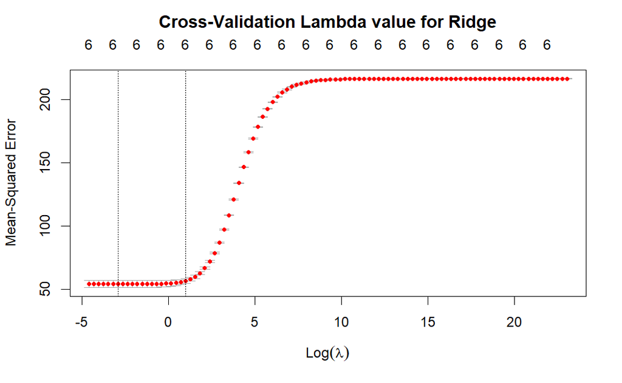

```r
plot(cv_ridge_fit)
title("Cross-Validation Lambda value for Ridge", line = 2.5)
```

```r
grid <- 10^seq(10, -2, length = 100)
cv_lasso_fit <- cv.glmnet(x_train, y_train, alpha = 1, lambda = grid)
cat("Min value for lambda(lasso):", cv_lasso_fit$lambda.min)
```

```
Min value for lambda(lasso): 0.01
```

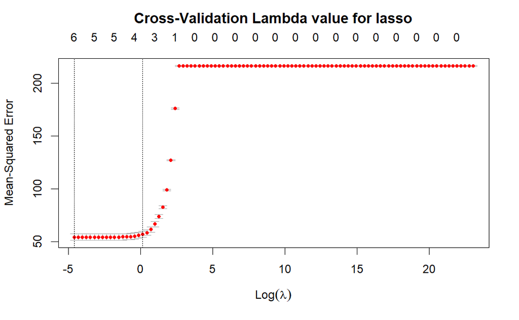

```r
plot(cv_lasso_fit)
title("Cross-Validation Lambda value for lasso", line = 2.5)
```

```r
lasso_model <- glmnet(x_train, y_train, alpha = 1, lambda = cv_lasso_fit$lambda.min)
ridge_model <- glmnet(x_train, y_train, alpha = 0, lambda = cv_ridge_fit$lambda.min)

predicted_fare_lasso <- predict(lasso_model, newx = x_test)
predicted_fare_ridge <- predict(ridge_model, newx = x_test)
```

```r
mse_lasso <- mean((y_test - predicted_fare_lasso)^2)
print(paste("Lasso Model - Mean Squared Error (MSE):", mse_lasso))
```

```
[1] "Lasso Model - Mean Squared Error (MSE): 59.6217527776917"
```

```r
mse_ridge <- mean((y_test - predicted_fare_ridge)^2)
print(paste("Ridge Model - Mean Squared Error (MSE):", mse_ridge))
```

```
[1] "Ridge Model - Mean Squared Error (MSE): 59.5996609382875"
```

```r
mae_lasso <- mean(abs(y_test - predicted_fare_lasso))
print(paste("Lasso Model - Mean Absolute Error (mae):", mae_lasso))
```

```
[1] "Lasso Model - Mean Absolute Error (mae): 3.90480010508161"
```

```r
mae_ridge <- mean(abs(y_test - predicted_fare_ridge))
print(paste("Ridge Model - Mean Absolute Error (mae):", mae_ridge))
```

```
[1] "Ridge Model - Mean Absolute Error (mae): 3.91656927120342"
```

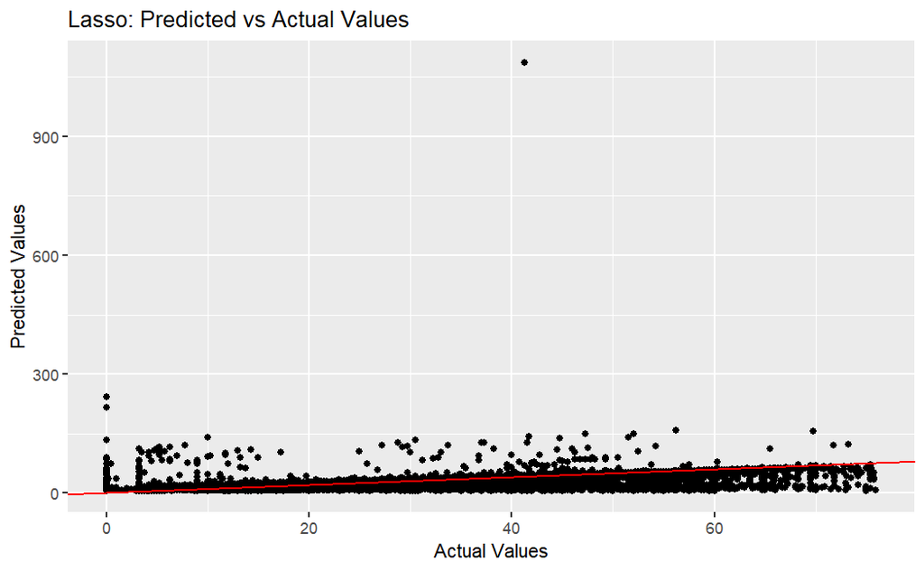

```r
df_lasso <- data.frame(Actual = y_test, Prediction = c(predicted_fare_lasso))
ggplot(df_lasso, aes(x = Actual, y = Prediction)) +
  geom_point() +
  geom_abline(intercept = 0, slope = 1, color = "red") +
  ggtitle("Lasso: Predicted vs Actual Values") +
  xlab("Actual Values") +
  ylab("Predicted Values")
```

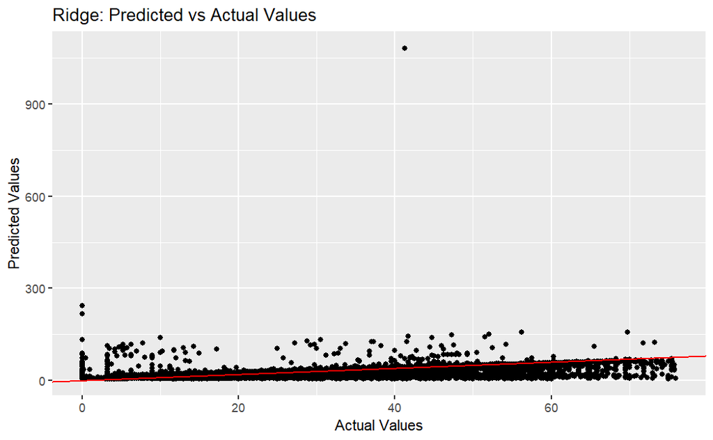

```r
df_ridge <- data.frame(Actual = y_test, Prediction = c(predicted_fare_ridge))
ggplot(df_ridge, aes(x = Actual, y = Prediction)) +
  geom_point() +
  geom_abline(intercept = 0, slope = 1, color = "red") +
  ggtitle("Ridge: Predicted vs Actual Values") +
  xlab("Actual Values") +
  ylab("Predicted Values")
```

### 3.4 Fare prediction using Splines

```r
smooth_spline <- lm(Fare ~ bs(Trip.Miles) + bs(Pickup.Community.Area) + bs(Dropoff.Community.Area) + bs(Trip.Minutes) + bs(Trip.Hour.Of.The.Day) + bs(Trip.Day.Of.The.Week), data = train_set)
summary(smooth_spline)
```

```
Call:
lm(formula = Fare ~ bs(Trip.Miles) + bs(Pickup.Community.Area) +
    bs(Dropoff.Community.Area) + bs(Trip.Minutes) + bs(Trip.Hour.Of.The.Day) +
    bs(Trip.Day.Of.The.Week), data = train_set)

Residuals:
     Min       1Q   Median       3Q      Max
-176.340   -2.429   -1.228    0.943   75.513

Coefficients:
                              Estimate Std. Error t value Pr(>|t|)
(Intercept)                    9.21724    0.10686  86.256   <2e-16 ***
bs(Trip.Miles)1              204.25237    0.80734 252.995   <2e-16 ***
bs(Trip.Miles)2              266.39408   13.97970  19.056   <2e-16 ***
bs(Trip.Miles)3              -11.62885    6.31410  -1.842   0.0655 .
bs(Pickup.Community.Area)1    -5.34996    0.18195 -29.404   <2e-16 ***
bs(Pickup.Community.Area)2     4.28221    0.14663  29.204   <2e-16 ***
bs(Pickup.Community.Area)3     4.04506    0.06636  60.959   <2e-16 ***
bs(Dropoff.Community.Area)1   -2.27359    0.18005 -12.628   <2e-16 ***
bs(Dropoff.Community.Area)2    3.88378    0.15883  24.452   <2e-16 ***
bs(Dropoff.Community.Area)3    2.01168    0.07502  26.816   <2e-16 ***
bs(Trip.Minutes)1            191.20892    0.76614 249.574   <2e-16 ***
bs(Trip.Minutes)2           -232.72788    3.04479 -76.435   <2e-16 ***
bs(Trip.Minutes)3            145.73525    3.42114  42.598   <2e-16 ***
bs(Trip.Hour.Of.The.Day)1     -1.58783    0.18499  -8.583   <2e-16 ***
bs(Trip.Hour.Of.The.Day)2     -6.07334    0.11269 -53.892   <2e-16 ***
bs(Trip.Hour.Of.The.Day)3     -0.08530    0.10865  -0.785   0.4324
bs(Trip.Day.Of.The.Week)1     -1.65784    0.11803 -14.045   <2e-16 ***
bs(Trip.Day.Of.The.Week)2     -1.94138    0.08793 -22.078   <2e-16 ***
bs(Trip.Day.Of.The.Week)3     -1.15625    0.06072 -19.042   <2e-16 ***
---
Signif. codes:  0 ‘***’ 0.001 ‘**’ 0.01 ‘*’ 0.05 ‘.’ 0.1 ‘ ’ 1

Residual standard error: 6.323 on 225064 degrees of freedom
Multiple R-squared:  0.8154,    Adjusted R-squared:  0.8154
F-statistic: 5.523e+04 on 18 and 225064 DF,  p-value: < 2.2e-16
```

```r
predicted_fare <- predict(smooth_spline, newdata = test_set)
mse <- mean((test_set$Fare - predicted_fare)^2)
print(paste("Mean Squared Error (MSE):", mse))
```

```
[1] "Mean Squared Error (MSE): 41.8511204925687"
```

```r
mae <- mean(abs(test_set$Fare - predicted_fare))
print(paste("Mean Absolute Error (MAE):", mae))
```

```
[1] "Mean Absolute Error (MAE): 3.44666467198102"
```

```r
rmse <- sqrt(mse)
print(paste("Root Mean Squared Error (RMSE):", rmse))
```

```
[1] "Root Mean Squared Error (RMSE): 6.4692441979391"
```

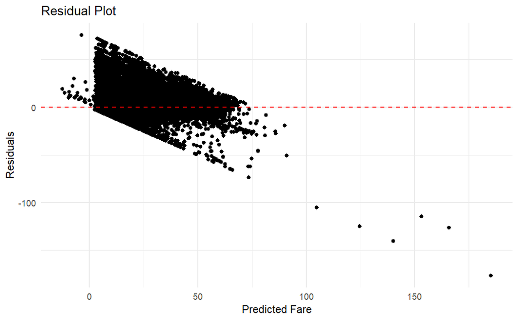

```r
train_predicted_fare <- predict(smooth_spline, newdata = train_set)
residuals <- residuals(smooth_spline)

plot_data <- data.frame(Predicted = train_predicted_fare, Residuals = residuals)

ggplot(plot_data, aes(x = Predicted, y = Residuals)) +
  geom_point() +
  geom_hline(yintercept = 0, linetype = "dashed", color = "red") +
  theme_minimal() +
  labs(title = "Residual Plot", x = "Predicted Fare", y = "Residuals")
```

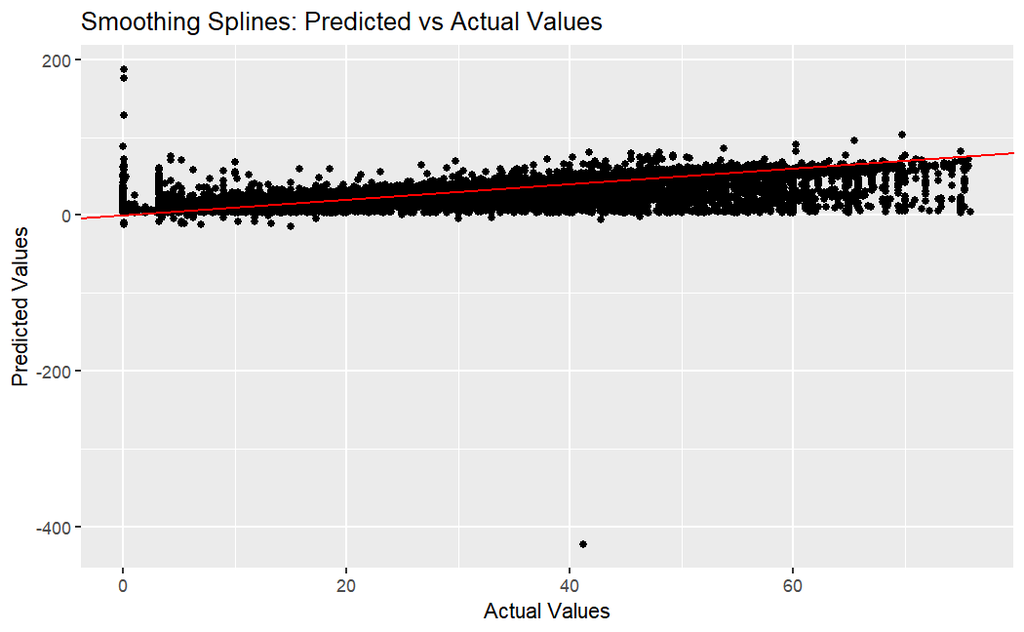

```r
df_splines <- data.frame(Actual = test_set$Fare, Predicted = predicted_fare)
ggplot(df_splines, aes(x = Actual, y = Predicted)) +
  geom_point() +
  geom_abline(intercept = 0, slope = 1, color = "red") +
  ggtitle("Smoothing Splines: Predicted vs Actual Values") +
  xlab("Actual Values") +
  ylab("Predicted Values")
```

As we see from the test set results, smoothing splines with an error of (+,-)$3.5 perform better than the linear models of lasso & ridge with an error of (+,-)$3.9. But the residual analysis of the smoothing splines show that the residuals might be following a particular pattern as they all fall in a certain region.

### 3. Tipping analysis

```r
model <- lm(Tips ~ ., data = selected_taxi_df)
summary(model)
```

[output not shown]

```r
summary(selected_taxi_df$Tips)
```

```
   Min. 1st Qu.  Median    Mean 3rd Qu.    Max.
  0.000   0.000   0.000   2.507   3.550  70.000
```

```r
model <- lm(Tips ~ ., data = selected_taxi_df)
summary(model)
```

[output not shown]